# DV-LAB3

KUNAL JAISWAL

02/02/2022

# Exercise-1.

```r
options(scipen=999) # turn-off scientific notation like 1e+48

library(ggplot2)

#geom_encircle
library(ggalt)
#marginal_plot
library(ggExtra)
#corrlelogram
library(ggcorrplot)

theme_set(theme_bw()) # pre-set the bw theme.
```

### Loading Dataset Orange

```r
df <- Orange
head(df)
```

```
##   Tree  age circumference
## 1    1  118            30
## 2    1  484            58
## 3    1  664            87
## 4    1 1004           115
## 5    1 1231           120
## 6    1 1372           142
```

### ScatterPlot

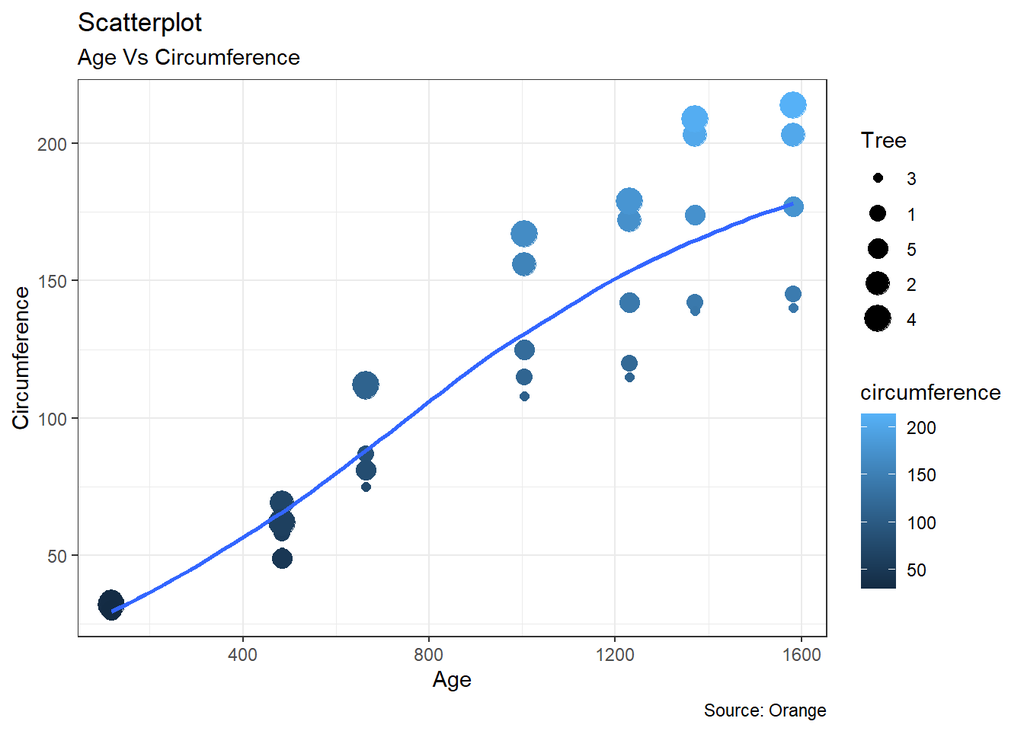

```r
# Scatterplot
gg <- ggplot(df, aes(x=age, y=circumference)) +
 geom_point(aes(col=circumference, size=Tree)) +
 geom_smooth(method="loess", se=F) +
 labs(subtitle="Age Vs Circumference",
 y="Circumference",
 x="Age",
 title="Scatterplot",
 caption = "Source: Orange")
plot(gg)
```

### ScatterPlot With Encircle

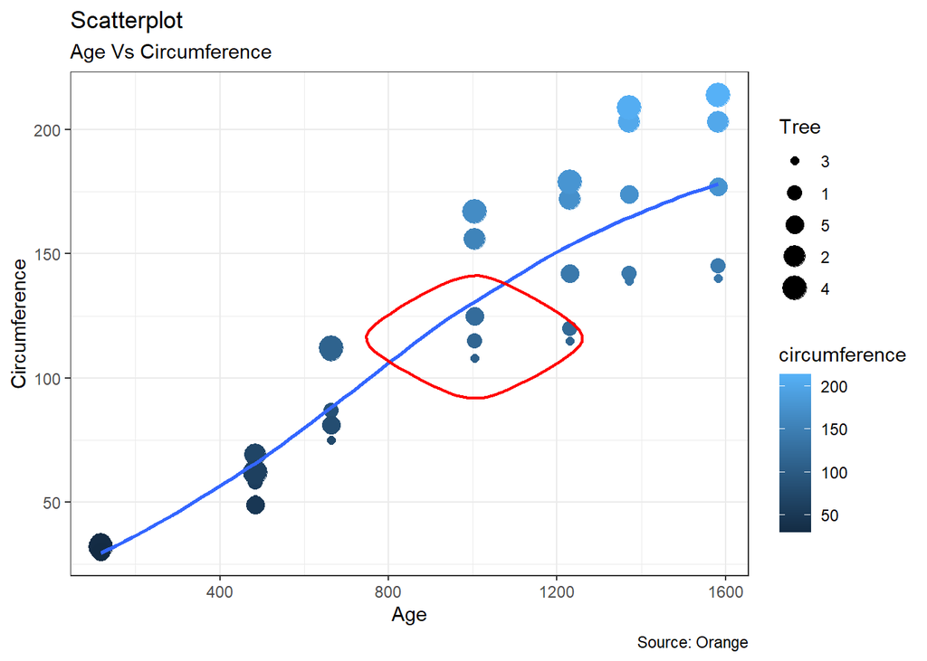

```r
df_select <- df[df$age > 800 &
 df$circumference <= 150 &
 df$age > 400 &
 df$age < 1200, ]



gg <- ggplot(df, aes(x=age, y=circumference)) +
 geom_point(aes(col=circumference, size=Tree)) +
 geom_smooth(method="loess", se=F) +
  geom_encircle(aes(x=age, y=circumference), data=df_select, color="red",
 size=2,
 expand=0.08)+
 labs(subtitle="Age Vs Circumference",
 y="Circumference",
 x="Age",
 title="Scatterplot",
 caption = "Source: Orange")
plot(gg)
```

### JitterPlot

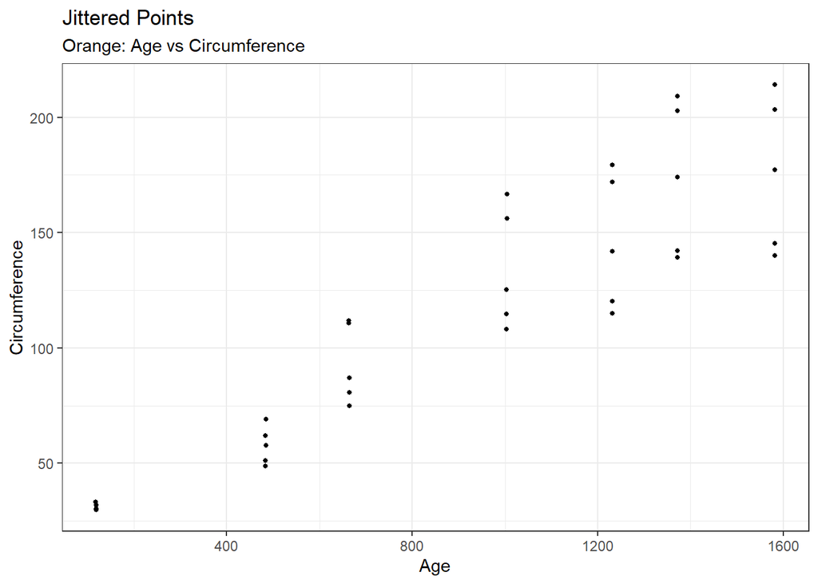

```r
g <- ggplot(df, aes(x=age, y=circumference))
g + geom_jitter(width = .5, size=1) +
 labs(subtitle="Orange: Age vs Circumference",
 y="Circumference",
 x="Age",
 title="Jittered Points")
```

### Count Plot

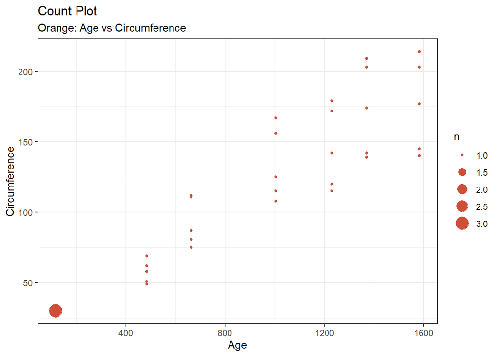

```r
g <- ggplot(df, aes(x=age, y=circumference))
g + geom_count(col="tomato3", show.legend=T) +
 labs(subtitle="Orange: Age vs Circumference",
 y="Circumference",
 x="Age",
 title="Count Plot")
```

### Bubble Chart

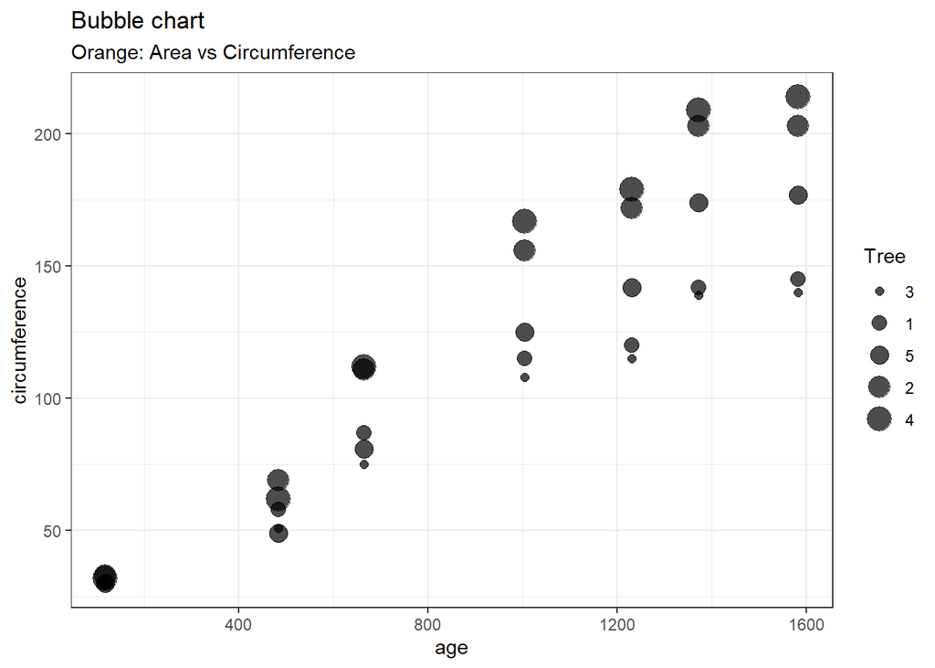

```r
g <- ggplot(df, aes(x=age, y=circumference, size=Tree)) +
  geom_point(alpha = 0.7)+
 labs(subtitle="Orange: Area vs Circumference",
 title="Bubble chart")
plot(g)
```

```r
#
```

### Marginal Histogram / Boxplot

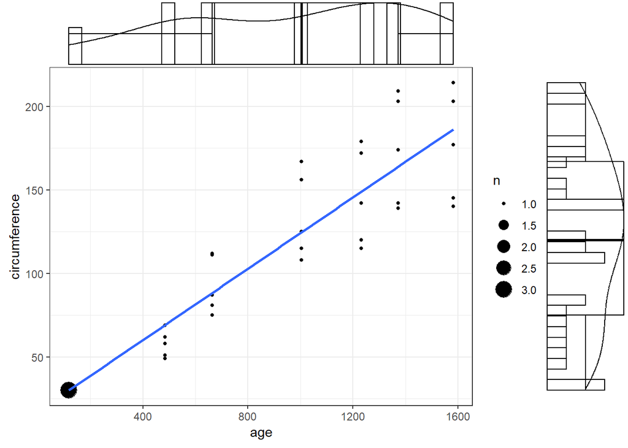

```r
df_select <- df[df$age >= 400 & df$circumference > 100, ]
g <- ggplot(df, aes(age, circumference)) +
 geom_count() +
 geom_smooth(method="lm", se=F)
ggMarginal(g, type = "histogram", fill="transparent")
ggMarginal(g, type = "boxplot", fill="transparent")
ggMarginal(g, type = "density", fill="transparent")
```

### Correlogram

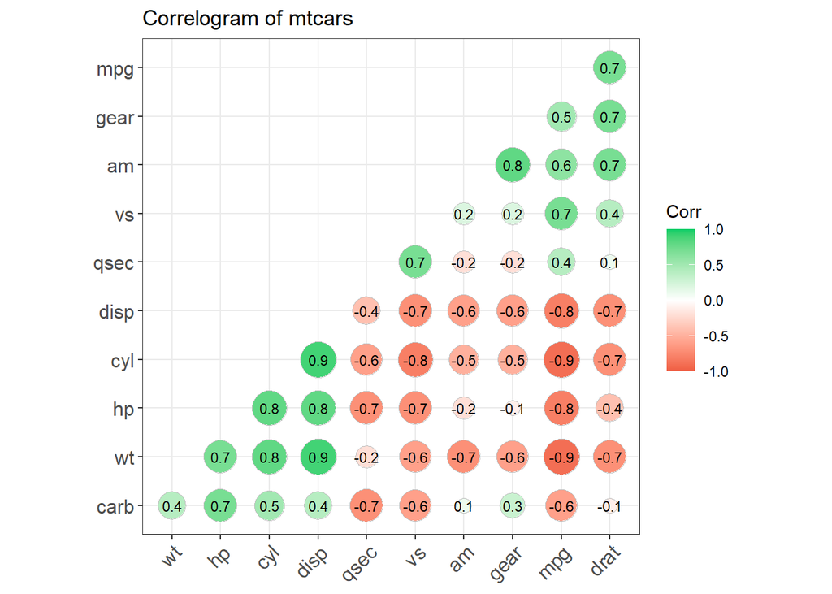

```r
# Correlation matrix

corr <- round(cor(mtcars), 1)
# Plot
ggcorrplot(corr, hc.order = TRUE,
 type = "lower",
 lab = TRUE,
 lab_size = 3,
 method="circle",
 colors = c("tomato2", "white", "springgreen3"),
 title="Correlogram of mtcars",
 ggtheme=theme_bw)
```

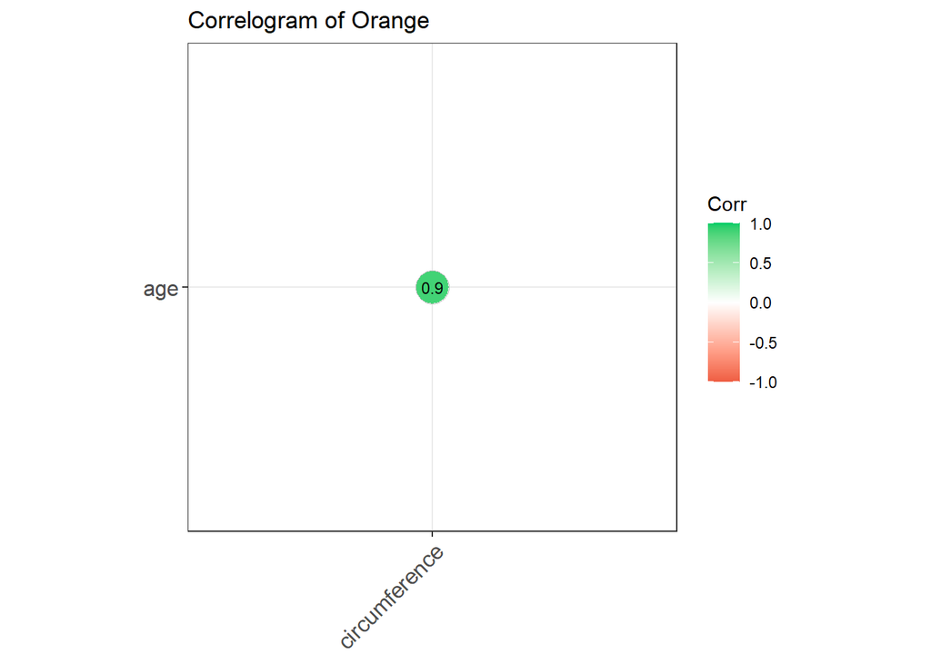

```r
corr <- round(cor(df[,-(1)]), 1)
# Plot
ggcorrplot(corr, hc.order = TRUE,
 type = "lower",
 lab = TRUE,
 lab_size = 3,
 method="circle",
 colors = c("tomato2", "white", "springgreen3"),
 title="Correlogram of Orange",
 ggtheme=theme_bw)
```

### Diverging bars

```r
df$age_z = round((df$age-mean(df$age))/(sd(df$age)),2)
head(df)
```

```
## Grouped Data: circumference ~ age | Tree
##   Tree  age circumference age_z
## 1    1  118            30 -1.63
## 2    1  484            58 -0.89
## 3    1  664            87 -0.52
## 4    1 1004           115  0.17
## 5    1 1231           120  0.63
## 6    1 1372           142  0.91
```

```r
df$age_type <- ifelse(df$age_z < 0, "normal age", "very old age") # above / below age flag
df <- df[order(df$age_z), ]
# convert to factor to retain sorted order in plot.
df$circumference_factor <- factor(df$circumference, levels = unique(df$circumference))
head(df,40)# sort
```

```
## Grouped Data: circumference ~ age | Tree
##    Tree  age circumference age_z     age_type circumference_factor
## 1     1  118            30 -1.63   normal age                   30
## 8     2  118            33 -1.63   normal age                   33
## 15    3  118            30 -1.63   normal age                   30
## 22    4  118            32 -1.63   normal age                   32
## 29    5  118            30 -1.63   normal age                   30
## 2     1  484            58 -0.89   normal age                   58
## 9     2  484            69 -0.89   normal age                   69
## 16    3  484            51 -0.89   normal age                   51
## 23    4  484            62 -0.89   normal age                   62
## 30    5  484            49 -0.89   normal age                   49
## 3     1  664            87 -0.52   normal age                   87
## 10    2  664           111 -0.52   normal age                  111
## 17    3  664            75 -0.52   normal age                   75
```

[output cut: 22 more lines]

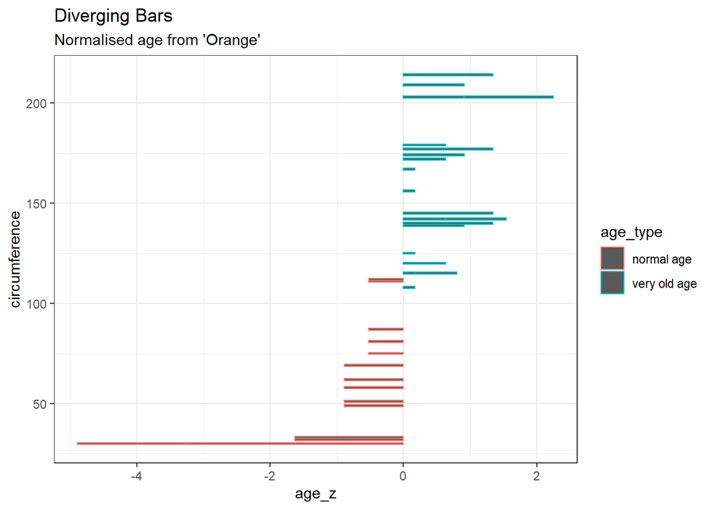

```r
ggplot(df, aes(x=circumference, y=age_z, color=age_type)) +
 geom_bar(stat='identity', aes(), width=1) +
 labs(subtitle="Normalised age from 'Orange'",
 title= "Diverging Bars") +
 coord_flip()
```

### Diverging Lollipop Chart

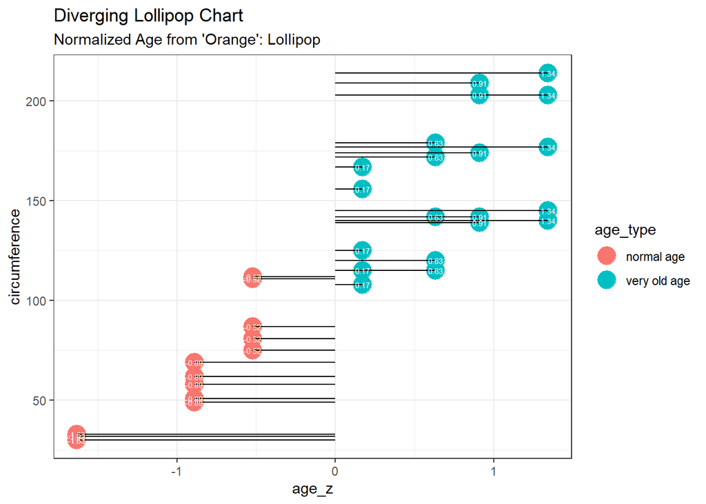

```r
ggplot(df, aes(x=circumference, y=age_z, color=age_type, label=age_z)) +
 geom_point(stat='identity', fill="black", size=6) +
 geom_segment(aes(y = 0,
 x = circumference,
 yend = age_z,
 xend = circumference),
 color = "black") +
 geom_text(color="white", size=2) +
 labs(title="Diverging Lollipop Chart",
 subtitle="Normalized Age from 'Orange': Lollipop") +
 coord_flip()
```

### Diverging Dot Plot

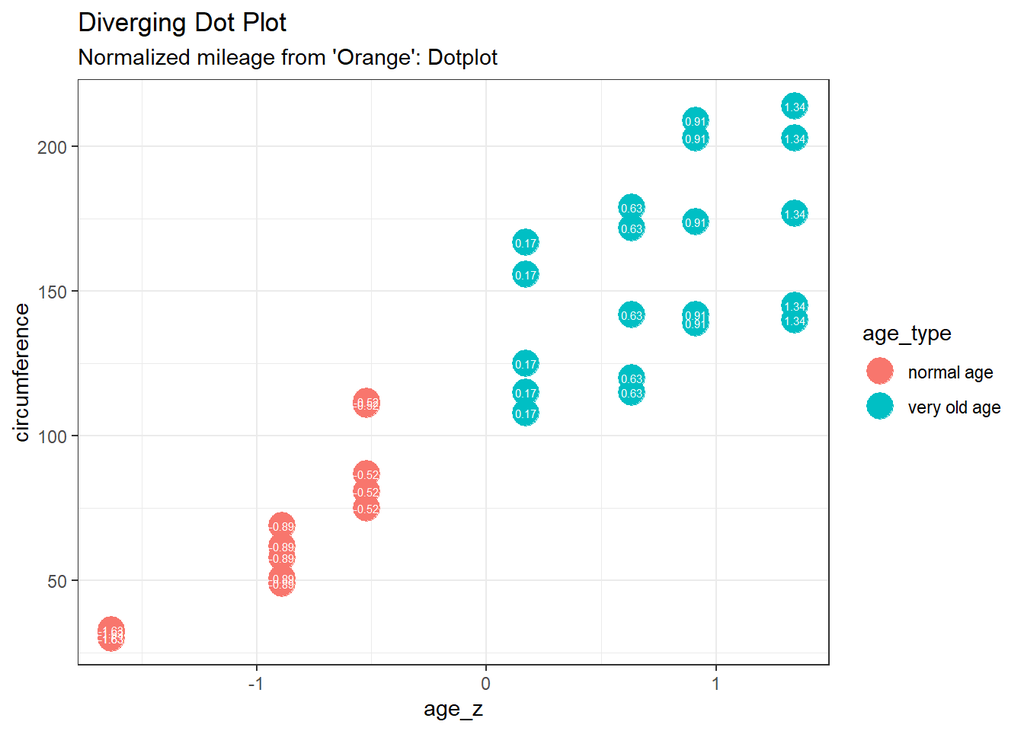

```r
ggplot(df, aes(x=circumference, y=age_z, color=age_type, label=age_z)) +
 geom_point(stat='identity', aes(col=age_type), size=6) +
 geom_text(color="white", size=2) +
 labs(title="Diverging Dot Plot",
 subtitle="Normalized mileage from 'Orange': Dotplot") +
 coord_flip()
```

### Area Chart

```r
library(quantmod)
```

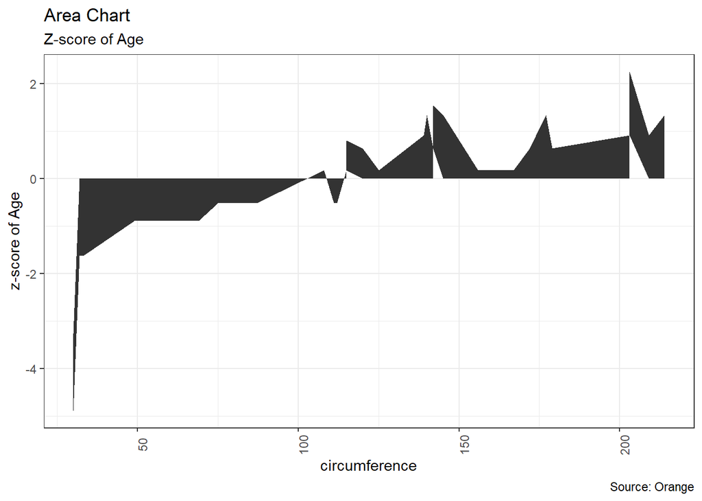

```r
ggplot(df, aes(circumference, age_z)) +
 geom_area() +
 theme(axis.text.x = element_text(angle=90)) +
 labs(title="Area Chart",
 subtitle = "Z-score of Age",
 y="z-score of Age",
 caption="Source: Orange")
```

# Excercise-2.

### 1. Look at Orange using either head or as.tibble() (you’ll have to run library(tidyverse) for that second option). What type of data are each of the columns?

```r
#describe function
library(Hmisc)
df<-Orange
head(df)
```

```
## Grouped Data: circumference ~ age | Tree
##   Tree  age circumference
## 1    1  118            30
## 2    1  484            58
## 3    1  664            87
## 4    1 1004           115
## 5    1 1231           120
## 6    1 1372           142
```

```r
summary(df)
```

```
##  Tree       age         circumference
##  3:7   Min.   : 118.0   Min.   : 30.0
##  1:7   1st Qu.: 484.0   1st Qu.: 65.5
##  5:7   Median :1004.0   Median :115.0
##  2:7   Mean   : 922.1   Mean   :115.9
##  4:7   3rd Qu.:1372.0   3rd Qu.:161.5
##        Max.   :1582.0   Max.   :214.0
```

```r
describe(df)
```

```
## df
##
##  3  Variables      35  Observations
## --------------------------------------------------------------------------------
## Tree
##        n  missing distinct
##       35        0        5
##
## lowest : 3 1 5 2 4, highest: 3 1 5 2 4
##
## Value        3   1   5   2   4
## Frequency    7   7   7   7   7
## Proportion 0.2 0.2 0.2 0.2 0.2
## --------------------------------------------------------------------------------
## age
##        n  missing distinct     Info     Mean      Gmd
##       35        0        7     0.98    922.1      566
##
## lowest :  118  484  664 1004 1231, highest:  664 1004 1231 1372 1582
##
## Value        118   484   664  1004  1231  1372  1582
## Frequency      5     5     5     5     5     5     5
## Proportion 0.143 0.143 0.143 0.143 0.143 0.143 0.143
## --------------------------------------------------------------------------------
## circumference
##        n  missing distinct     Info     Mean      Gmd      .05      .10
##       35        0       30    0.999    115.9    66.97     30.0     32.4
##      .25      .50      .75      .90      .95
##     65.5    115.0    161.5    193.4    204.8
##
## lowest :  30  32  33  49  51, highest: 177 179 203 209 214
## --------------------------------------------------------------------------------
```

### 2. Find the mean, standard deviation, and standard error of tree circumference

```r
library(dplyr)
df %>% group_by(Tree) %>% summarise(Mean_Circumference = mean(circumference))
```

```
## # A tibble: 5 x 2
##   Tree  Mean_Circumference
##   <ord>              <dbl>
## 1 3                   94
## 2 1                   99.6
## 3 5                  111.
## 4 2                  135.
## 5 4                  139.
```

```r
df %>% group_by(Tree) %>% summarise(Standard_Deviation_of_Circumference = sd(circumference))
```

```
## # A tibble: 5 x 2
##   Tree  Standard_Deviation_of_Circumference
##   <ord>                               <dbl>
## 1 3                                    43.0
## 2 1                                    43.3
## 3 5                                    58.9
## 4 2                                    66.3
## 5 4                                    71.9
```

```r
df %>% group_by(Tree) %>% summarise(Standard_Error_Circumference = (sd(circumference)/sqrt(length(df$circumference))))
```

```
## # A tibble: 5 x 2
##   Tree  Standard_Error_Circumference
##   <ord>                        <dbl>
## 1 3                             7.27
## 2 1                             7.32
## 3 5                             9.95
## 4 2                            11.2
## 5 4                            12.2
```

### 3. Make a linear model which describes circumference (the response) as a function of age (the predictor). Save it as an object with <-, then print the object out by typing its name. What do those coefficients mean?

```r
lr_model1 = lm(circumference~age, df)
print(lr_model1)
```

```
##
## Call:
## lm(formula = circumference ~ age, data = df)
##
## Coefficients:
## (Intercept)          age
##     17.3997       0.1068
```

```r
print(' In linear regression, coefficients are the values that multiply the predictor values.')
```

```
## [1] " In linear regression, coefficients are the values that multiply the predictor values."
```

```r
print('Like:  circumference=coef(age)*age+intercept')
```

```
## [1] "Like:  circumference=coef(age)*age+intercept"
```

### 4. Make another linear model describing age as a function of circumference. Save this as a different object.

```r
lr_model2 = lm(age~circumference, df)
print(lr_model2)
```

```
##
## Call:
## lm(formula = age ~ circumference, data = df)
##
## Coefficients:
##   (Intercept)  circumference
##        16.604          7.816
```

```r
print(' In linear regression, coefficients are the values that multiply the predictor values.')
```

```
## [1] " In linear regression, coefficients are the values that multiply the predictor values."
```

```r
print('Like:  age=coef(circumference)*circumference+intercept')
```

```
## [1] "Like:  age=coef(circumference)*circumference+intercept"
```

### 5. Call summary() on both of your model objects. What do you notice

```r
summary(lr_model1)
```

```
##
## Call:
## lm(formula = circumference ~ age, data = df)
##
## Residuals:
##     Min      1Q  Median      3Q     Max
## -46.310 -14.946  -0.076  19.697  45.111
##
## Coefficients:
##              Estimate Std. Error t value           Pr(>|t|)
## (Intercept) 17.399650   8.622660   2.018             0.0518 .
## age          0.106770   0.008277  12.900 0.0000000000000193 ***
## ---
## Signif. codes:  0 '***' 0.001 '**' 0.01 '*' 0.05 '.' 0.1 ' ' 1
##
## Residual standard error: 23.74 on 33 degrees of freedom
## Multiple R-squared:  0.8345, Adjusted R-squared:  0.8295
## F-statistic: 166.4 on 1 and 33 DF,  p-value: 0.00000000000001931
```

```r
summary(lr_model2)
```

```
##
## Call:
## lm(formula = age ~ circumference, data = df)
##
## Residuals:
##     Min      1Q  Median      3Q     Max
## -317.88 -140.90  -17.20   96.54  471.16
##
## Coefficients:
##               Estimate Std. Error t value           Pr(>|t|)
## (Intercept)    16.6036    78.1406   0.212              0.833
## circumference   7.8160     0.6059  12.900 0.0000000000000193 ***
## ---
## Signif. codes:  0 '***' 0.001 '**' 0.01 '*' 0.05 '.' 0.1 ' ' 1
##
## Residual standard error: 203.1 on 33 degrees of freedom
## Multiple R-squared:  0.8345, Adjusted R-squared:  0.8295
## F-statistic: 166.4 on 1 and 33 DF,  p-value: 0.00000000000001931
```

```r
print('We Observed that both have same R2 score and different Coefficients')
```

```
## [1] "We Observed that both have same R2 score and different Coefficients"
```

### 6. Does this mean that trees growing makes them get older? Does a tree getting older make it grow larger? Or are these just correlations?

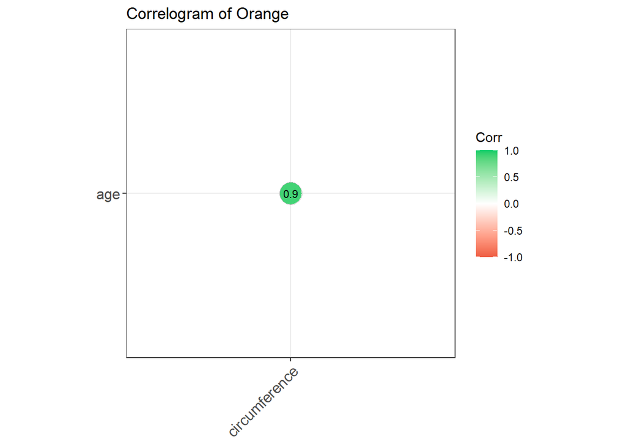

```r
corr <- round(cor(df[,-(1)]), 1)
# Plot
ggcorrplot(corr,
 type = "lower",
 lab = TRUE,
 lab_size = 3,
 method="circle",
 colors = c("tomato2", "white", "springgreen3"),
 title="Correlogram of Orange",
 ggtheme=theme_bw)
```

```r
print('Since we can see that they have 0.9135 correlation score means they are highly correlated to each other and as we could see by both of their accuracy scores have exact same values and Hence we can say that both are depent on each other positively as one grows another also grows or increases')
```

```
## [1] "Since we can see that they have 0.9135 correlation score means they are highly correlated to each other and as we could see by both of their accuracy scores have exact same values and Hence we can say that both are depent on each other positively as one grows another also grows or increases"
```

### 7. Does the significant p value prove that trees growing makes them get older? Why not?

```r
print('As the p-value is much less than 0.05 i.e 0.00000000000001931, we reject the null hypothesis that β = 0. Hence there is a significant relationship between the variables in the linear regression model of the data set Orange')
```

```
## [1] "As the p-value is much less than 0.05 i.e 0.00000000000001931, we reject the null hypothesis that ß = 0. Hence there is a significant relationship between the variables in the linear regression model of the data set Orange"
```

```r
print('Since Null Hypothesis is rejected and we accept Alternate Hypothesis i.e there is significant relationship between the variables in the linear regression model')
```

```
## [1] "Since Null Hypothesis is rejected and we accept Alternate Hypothesis i.e there is significant relationship between the variables in the linear regression model"
```

```r
print('No significant p-value does not prove that trees growing makes them get older , because it just tells whether they(response and predictors) are dependent or not does not tell about correlation between them for that we use Coefficients if they are positive that means increase in one increases other or vice-versa. Similarly if Coefficients are negative that means increase in one leads to decrease in other or vice-versa.')
```

[output not shown]

##### You reached to the end of the document, knit the worked out document into html format and uplaod the html file.

```
## [1] "2022-02-02 14:03:32 IST"
```

```
## [1] "DESKTOP-9EVC08B"
```

```
## [1] "kunal"
```